# An Ensemble Model to Predict the Length of Stay

DA5030

Sharad Raina

Summer 2024

# Introduction

Accurately predicting the length of stay (LOS) for patients in a healthcare facility is crucial for optimizing resource management, improving patient care, and ensuring operational efficiency. In modern healthcare, the ability to foresee a patient’s length of stay based on various health metrics allows hospitals to better allocate beds, schedule procedures, manage staff, and plan discharges effectively.

This project aims to develop predictive models that estimate the length of stay for patients using a range of healthcare measures, including re-admission counts, glucose levels, kidney function, and other relevant health indicators. By analyzing these variables, we can identify patterns and correlations that influence a patient’s duration in the hospital, thereby providing insights that can help in decision-making processes.

The primary goal is to create a reliable prediction model that can assist healthcare providers in anticipating the needs of their patients more accurately, ultimately leading to better healthcare outcomes and more efficient use of hospital resources.

# Project Approach

This project has been created in 3 iterations to assess the isolated impact of each iteration on model results. The models created are Linear Regression, Random Forest and Gradient Boosting.

The 1st iteration is done with minimal data prep and seeing model performance through R square and RMSE. In 2nd iteration extensive data prep is done and the above parameters are used to compare results. In the last iteration PCA has been performed on the dataset and the new components obtained have been used in model training and evaluation. Again the results are obtained using same metrics and analysis is done to assess individual impact of PCA on the model performance and its comparison with above 2 iterations.

There is also creation of an ensemble model that combines the predictive power of the 3 best models I got and averages them to predict the length of stay of a patient.

# 1st Iteration

### Data Acquisition

#### Loading CSV

```r
# Getting URL
url = "https://drive.google.com/uc?export=download&id=14NC3dUvpv0UZx-hBox1UDvJ91ktfgpFE"


# Creating dataset
length_of_stay = read.csv(url)

# First 6 observations
# head(length_of_stay)


# Creating copy to be used later
length_of_stay_copy = length_of_stay
```

### Data Exploration

```r
# Getting structure of data
str(length_of_stay)
```

```
  'data.frame': 100000 obs. of  28 variables:
   $ eid                       : int  1 2 3 4 5 6 7 8 9 10 ...
   $ vdate                     : chr  "8/29/2012" "5/26/2012" "9/22/2012" "8/9/2012" ...
   $ rcount                    : chr  "0" "5+" "1" "0" ...
   $ gender                    : chr  "F" "F" "F" "F" ...
   $ dialysisrenalendstage     : int  0 0 0 0 0 0 0 0 0 0 ...
   $ asthma                    : int  0 0 0 0 0 0 0 0 0 0 ...
   $ irondef                   : int  0 0 0 0 0 0 0 0 0 0 ...
   $ pneum                     : int  0 0 0 0 1 0 0 0 0 0 ...
   $ substancedependence       : int  0 0 0 0 0 0 0 0 1 0 ...
   $ psychologicaldisordermajor: int  0 0 0 0 1 0 0 1 0 0 ...
   $ depress                   : int  0 0 0 0 0 0 0 0 0 0 ...
   $ psychother                : int  0 0 0 0 0 0 0 0 0 0 ...
   $ fibrosisandother          : int  0 0 0 0 0 0 0 0 0 0 ...
   $ malnutrition              : int  0 0 0 0 0 0 0 0 0 0 ...
   $ hemo                      : int  0 0 0 0 0 0 0 0 0 0 ...
   $ hematocrit                : num  11.5 9 8.4 11.9 9.1 ...
   $ neutrophils               : num  14.2 4.1 8.9 9.4 9.05 17.8 8.5 7.15 9.4 8.5 ...
   $ sodium                    : num  140 137 133 139 139 ...
   $ glucose                   : num  192.5 94.1 130.5 163.4 94.9 ...
   $ bloodureanitro            : num  12 8 12 12 11.5 11 6 11 12 10 ...
   $ creatinine                : num  1.391 0.943 1.066 0.907 1.243 ...
   $ bmi                       : num  30.4 28.5 28.8 28 30.3 ...
   $ pulse                     : int  96 61 64 76 67 83 68 63 69 65 ...
   $ respiration               : num  6.5 6.5 6.5 6.5 5.6 6.1 6.5 6 6.5 6.5 ...
   $ secondarydiagnosisnonicd9 : int  4 1 2 1 2 1 4 3 1 0 ...
   $ discharged                : chr  "9/1/2012" "6/2/2012" "9/25/2012" "8/10/2012" ...
   $ facid                     : chr  "B" "A" "B" "A" ...
   $ lengthofstay              : int  3 7 3 1 4 6 6 3 3 2 ...
```

- The dataset consists of *100000 rows* and *28 columns*.
- The **vdate , discharged** column store *dates in character* format hence, data prep required here.
- **rcount** variable records no. of **re-admissions** patient had and is present in **character format**, requires further investigation.
- Most of the data is in numerical format but looking at columns like **sodium, glucose, creatinine**, scaling is a requirement.
- **eid** column as per data dictionary is an index number hence not adding any information and would be removed.

```r
# Summary of the data in terms of mean,median etc.
summary( length_of_stay )
```

```
##       eid            vdate              rcount             gender
##  Min.   :     1   Length:100000      Length:100000      Length:100000
##  1st Qu.: 25001   Class :character   Class :character   Class :character
##  Median : 50000   Mode  :character   Mode  :character   Mode  :character
##  Mean   : 50000
##  3rd Qu.: 75000
##  Max.   :100000
##  dialysisrenalendstage     asthma           irondef            pneum
##  Min.   :0.00000       Min.   :0.00000   Min.   :0.00000   Min.   :0.00000
##  1st Qu.:0.00000       1st Qu.:0.00000   1st Qu.:0.00000   1st Qu.:0.00000
##  Median :0.00000       Median :0.00000   Median :0.00000   Median :0.00000
##  Mean   :0.03642       Mean   :0.03527   Mean   :0.09494   Mean   :0.03945
##  3rd Qu.:0.00000       3rd Qu.:0.00000   3rd Qu.:0.00000   3rd Qu.:0.00000
##  Max.   :1.00000       Max.   :1.00000   Max.   :1.00000   Max.   :1.00000
##  substancedependence psychologicaldisordermajor    depress
##  Min.   :0.00000     Min.   :0.000              Min.   :0.00000
##  1st Qu.:0.00000     1st Qu.:0.000              1st Qu.:0.00000
##  Median :0.00000     Median :0.000              Median :0.00000
##  Mean   :0.06306     Mean   :0.239              Mean   :0.05166
##  3rd Qu.:0.00000     3rd Qu.:0.000              3rd Qu.:0.00000
##  Max.   :1.00000     Max.   :1.000              Max.   :1.00000
##    psychother      fibrosisandother   malnutrition          hemo
##  Min.   :0.00000   Min.   :0.00000   Min.   :0.00000   Min.   :0.00
##  1st Qu.:0.00000   1st Qu.:0.00000   1st Qu.:0.00000   1st Qu.:0.00
##  Median :0.00000   Median :0.00000   Median :0.00000   Median :0.00
##  Mean   :0.04939   Mean   :0.00479   Mean   :0.04948   Mean   :0.08
##  3rd Qu.:0.00000   3rd Qu.:0.00000   3rd Qu.:0.00000   3rd Qu.:0.00
##  Max.   :1.00000   Max.   :1.00000   Max.   :1.00000   Max.   :1.00
##    hematocrit     neutrophils         sodium         glucose
##  Min.   : 4.40   Min.   :  0.10   Min.   :124.9   Min.   : -1.006
##  1st Qu.:10.90   1st Qu.:  7.70   1st Qu.:135.9   1st Qu.:121.682
##  Median :11.90   Median :  9.40   Median :137.9   Median :142.089
##  Mean   :11.98   Mean   : 10.18   Mean   :137.9   Mean   :141.963
##  3rd Qu.:12.90   3rd Qu.: 11.50   3rd Qu.:139.9   3rd Qu.:162.181
##  Max.   :24.10   Max.   :245.90   Max.   :151.4   Max.   :271.444
##  bloodureanitro    creatinine          bmi            pulse
##  Min.   :  1.0   Min.   :0.2198   Min.   :21.99   Min.   : 21.00
##  1st Qu.: 11.0   1st Qu.:0.9647   1st Qu.:28.45   1st Qu.: 66.00
##  Median : 12.0   Median :1.0988   Median :29.81   Median : 73.00
##  Mean   : 14.1   Mean   :1.0993   Mean   :29.81   Mean   : 73.44
##  3rd Qu.: 14.0   3rd Qu.:1.2349   3rd Qu.:31.16   3rd Qu.: 81.00
##  Max.   :682.5   Max.   :2.0352   Max.   :38.94   Max.   :130.00
##   respiration     secondarydiagnosisnonicd9  discharged
##  Min.   : 0.200   Min.   : 0.000            Length:100000
##  1st Qu.: 6.500   1st Qu.: 1.000            Class :character
##  Median : 6.500   Median : 1.000            Mode  :character
##  Mean   : 6.494   Mean   : 2.123
##  3rd Qu.: 6.500   3rd Qu.: 3.000
##  Max.   :10.000   Max.   :10.000
##     facid            lengthofstay
##  Length:100000      Min.   : 1.000
##  Class :character   1st Qu.: 2.000
##  Mode  :character   Median : 4.000
##                     Mean   : 4.001
##                     3rd Qu.: 6.000
##                     Max.   :17.000
```

- **secondarydiagnosisnonicd9** and **neutrophils** column has noticebale difference in mean and median hence,can be due to outliers or high values recorded. Such distribution is expected to not give a bell shaped - curve which is explored further.
- No NA values are seen in the dataset.
- **Glucose** columns records minimum value of -1 which can be considered as an error and would get treated during outliers treatment.

#### No NA values

```r
# Checking for NA values
#colSums(is.na(length_of_stay))


# 0 NA values
sum(is.na(length_of_stay))
```

```
## [1] 0
```

#### Char to Date

```r
# Converting date to appropriate format
length_of_stay$vdate =  as.Date( length_of_stay$vdate  , format = "%m/%d/%Y" )


length_of_stay$discharged = as.Date( length_of_stay$discharged , format = "%m/%d/%Y" )
```

#### Char to Int

```r
# Distribution of re-admission variable
prop.table(table(length_of_stay$rcount))*100
```

```
##
##      0      1      2      3      4     5+
## 55.031 15.007  9.987  8.047  6.941  4.987
```

```r
# Converting to numeric
length_of_stay$rcount = as.numeric(stringr::str_replace_all( length_of_stay$rcount , pattern = "\\+" , replacement = "" ) )
```

- *re-admission* column records the no. of **previous re-admissions** the patient had within last 180 days and since this feature can have a **major impact** on deciding length of stay ( target variable ), its relationship is investigated below.
- Keeping it as **numeric** helps in **limiting** the excess **dummy** columns that would be created but would make no sense if there is no **ordinal nature** to this data and there is no linear relationship with target variable.
- If **no linear relationship** can be seen then, its better to convert it to **factor** and see there individual impact.
- More than **55 %** of patients in the dataset have had *0 previous re-admissions*.

#### Deciding whether to keep it as factor or numeric

```r
# Loading library
library(dplyr)


# Loading library
library(ggplot2)

# Avg length of stay for each re-admssion count
avg_los = length_of_stay %>%

  group_by(rcount) %>%

  summarise(avg_lengthofstay = round(mean(lengthofstay, na.rm = TRUE)))

avg_los
```

```
## # A tibble: 6 × 2
##   rcount avg_lengthofstay
##    <dbl>            <dbl>
## 1      0                3
## 2      1                4
## 3      2                5
## 4      3                6
## 5      4                7
## 6      5                8
```

##### There is definite increase in avg length of stay with increase in r count.

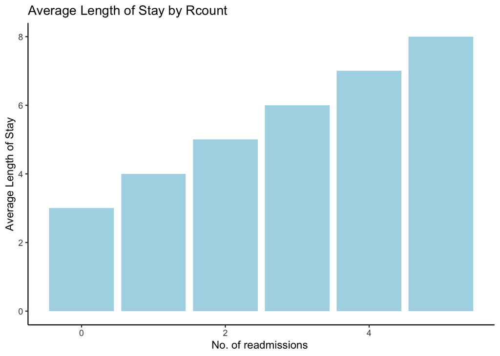

```r
# Plotting to check a linear relationship
ggplot(avg_los, aes( x = rcount, y = avg_lengthofstay  )  ) +

  geom_col( fill = "lightblue" ) +

  labs(x = "No. of readmissions ", y = "Average Length of Stay", title = "Average Length of Stay by Rcount") +

  theme_classic()
```

##### Positive trend is witnessed in between r count and length of stay

```r
# Pearson co-relation
cor( length_of_stay$rcount , length_of_stay$lengthofstay)
```

```
## [1] 0.7495141
```

- Pearson co - relations reveals a strong positive co-relation value of 0.74.
- Hence keeping it as numeric is justified as I want this ordinal nature of data to be preserved and captured by my model.

#### Gender to dummy encoding

```r
# Encoding gender variable
length_of_stay$gender  = ifelse( length_of_stay$gender == "F" , 0 , 1 )


# Converting to factor so that co-efficients can be estimated correctly
length_of_stay$gender = factor( length_of_stay$gender  , levels = c( 0 , 1 ) )
```

- Column **eid** represents unique id of hospital admission and in my understanding does not impact length of stay of that patient. It can be used to uniquely identify a patient but since that is not the task in hand, its better to get rid of it.
- Columns like **vdate and discharged** represent admission and discharge dates for the patient which information is captured by **length of stay variable** which is a difference of both these columns. Hence, I have decided to get rid of them as well.

#### Facility ID variable

```r
# Distribution of variable
prop.table(table( length_of_stay$facid ))*100
```

```
##
##      A      B      C      D      E
## 30.035 30.012  4.699  4.499 30.755
```

```r
# Creating dummies for facility id column
length_of_stay$facid = ifelse(length_of_stay$facid == "A", 1,

                                       ifelse(length_of_stay$facid == "B", 2,

                                       ifelse(length_of_stay$facid == "C", 3,

                                       ifelse(length_of_stay$facid == "D", 4,

                                       ifelse(length_of_stay$facid == "E", 5, NA)))))


# Converting to factor
length_of_stay$facid = factor(length_of_stay$facid)
```

- Facilities A , B and E have 90% of patient admissions.
- Facility ID variable records ID’s of specific healthcare facilities where the patient was admitted.
- Since quality of care provided at a healthcare facility can impact length of stay, have decided to keep this column.

### Data Visualization

#### Visualizing distribution of categorical encoded variables

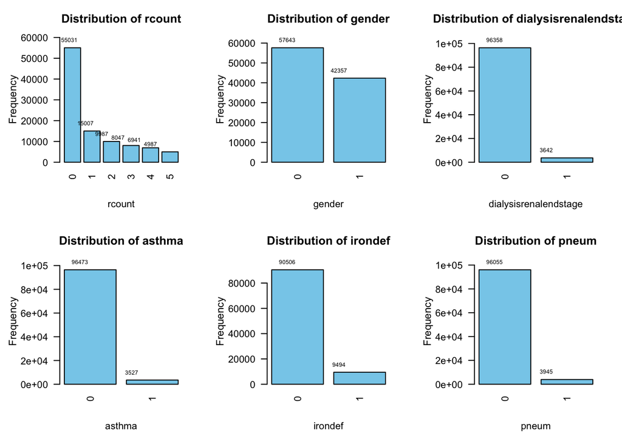

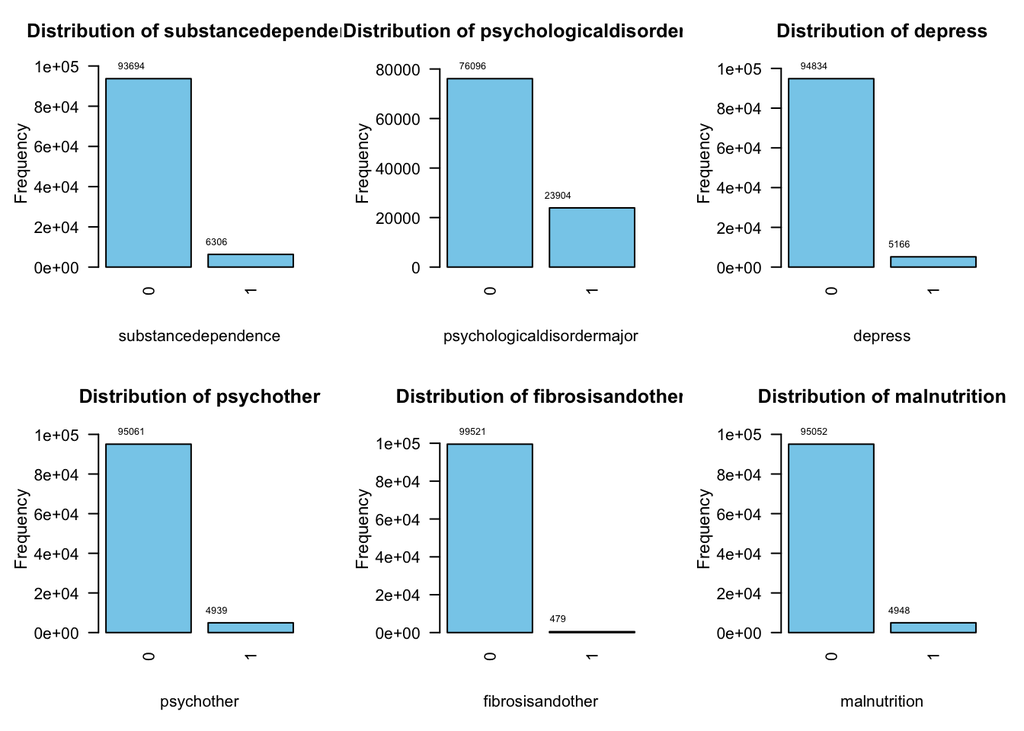

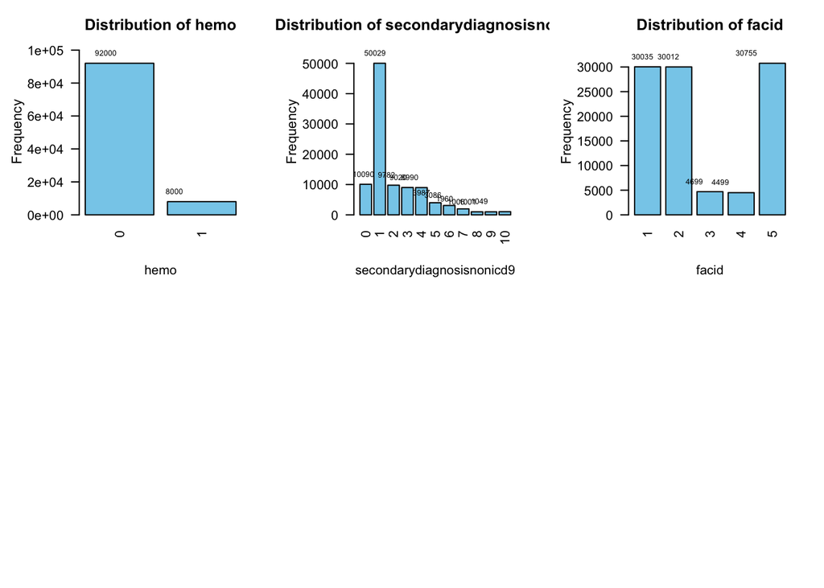

- r count variable is dominated by 0 re - admissions.
- Gender variable seems to have a balanced representation of males and females.
- Rest of the columns showing distribution of asthma, iron deficiency, pneumonia etc. are imbalanced indicating most patients in the dataset do not suffer from these diseases.

#### Visualizing distribution of continous variables

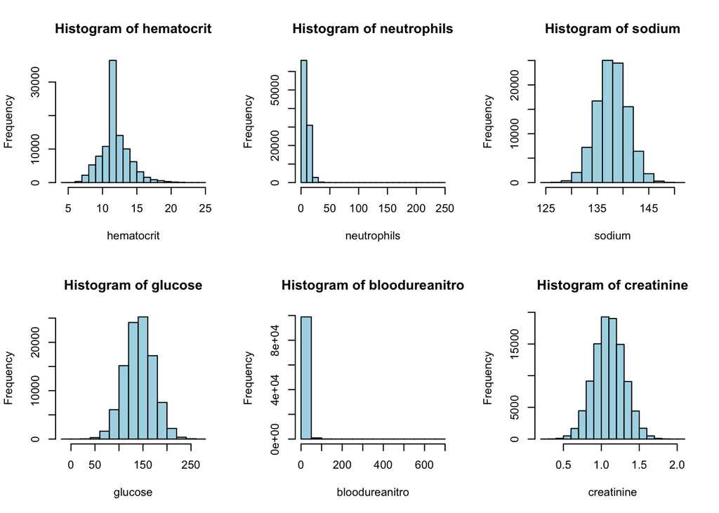

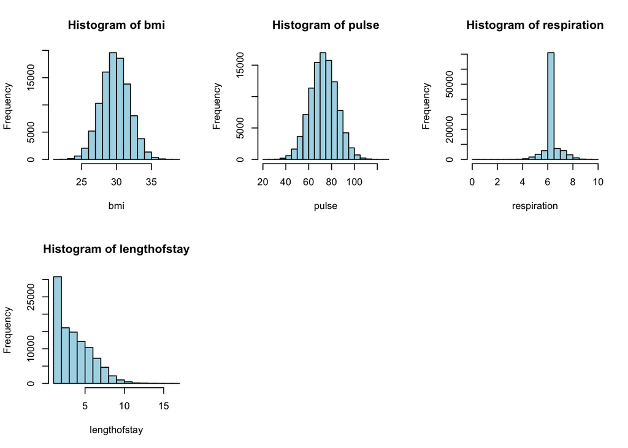

#### Boxplot for outlier inspection

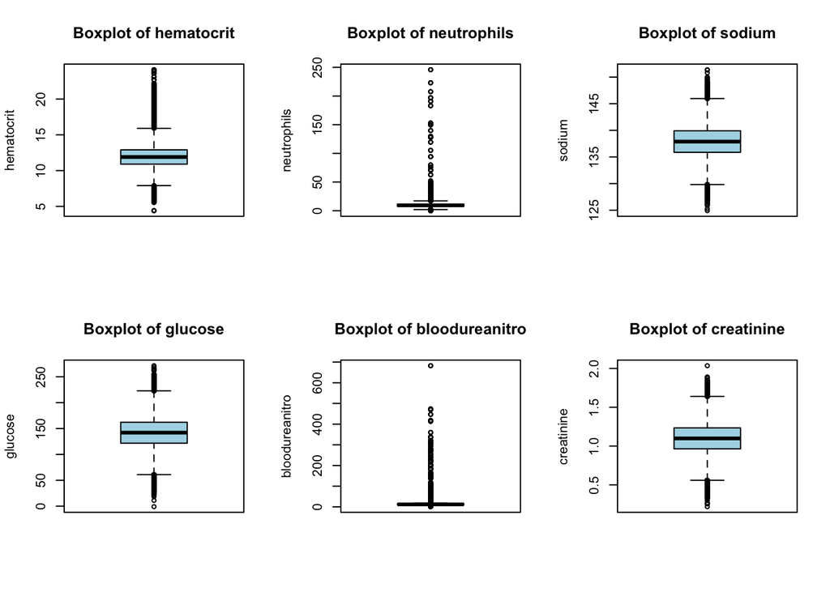

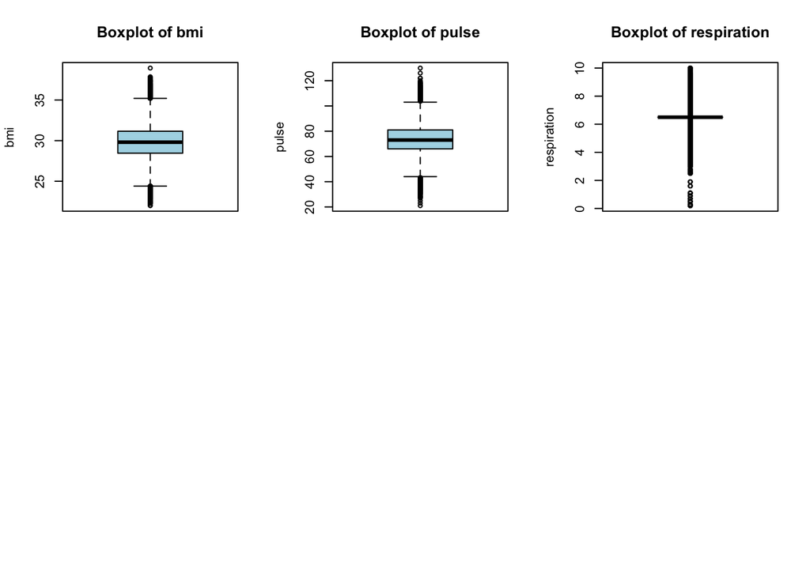

#### Train - test Split

```r
# Setting seed for reproducibility
set.seed(1234)

# Index for train test split
index = createDataPartition( length_of_stay$lengthofstay , p = 0.70 , list = FALSE )

# TRaining data
train_data = length_of_stay[index , ]

# Testing data
test_data = length_of_stay[ - index , ]


dim( train_data)
```

```
## [1] 70001    25
```

```r
dim( test_data )
```

```
## [1] 29999    25
```

### Model Building on basic data prep

#### Building models and using them for baseline reference

```r
model = lm( lengthofstay ~. , data = train_data )


summary(model)
```

```
##
## Call:
## lm(formula = lengthofstay ~ ., data = train_data)
##
## Residuals:
##     Min      1Q  Median      3Q     Max
## -6.1163 -0.8499 -0.2513  0.6093  9.1627
##
## Coefficients:
##                              Estimate Std. Error t value Pr(>|t|)
## (Intercept)                 1.7409231  0.2219065   7.845 4.38e-15 ***
## rcount                      1.1503329  0.0028326 406.105  < 2e-16 ***
## gender1                     0.0647066  0.0095104   6.804 1.03e-11 ***
## dialysisrenalendstage       0.7149484  0.0256167  27.909  < 2e-16 ***
## asthma                      0.3747728  0.0286638  13.075  < 2e-16 ***
## irondef                     0.3695062  0.0183964  20.086  < 2e-16 ***
## pneum                       0.4281487  0.0258857  16.540  < 2e-16 ***
## substancedependence         0.5990211  0.0208919  28.672  < 2e-16 ***
## psychologicaldisordermajor  0.7741689  0.0184059  42.061  < 2e-16 ***
## depress                     0.3634729  0.0209476  17.352  < 2e-16 ***
## psychother                  0.5857017  0.0250399  23.391  < 2e-16 ***
## fibrosisandother            0.8469668  0.0663043  12.774  < 2e-16 ***
## malnutrition                0.3123416  0.0229279  13.623  < 2e-16 ***
## hemo                        1.2240410  0.0174062  70.322  < 2e-16 ***
## secondarydiagnosisnonicd9   0.0003428  0.0021333   0.161 0.872329
## facid2                      0.0126155  0.0112614   1.120 0.262615
## facid3                      1.0910693  0.0258158  42.264  < 2e-16 ***
## facid4                      0.9089208  0.0293274  30.992  < 2e-16 ***
## facid5                      0.8059781  0.0202572  39.787  < 2e-16 ***
## hematocrit                  0.0088084  0.0024478   3.599 0.000320 ***
## neutrophils                 0.0217286  0.0008550  25.414  < 2e-16 ***
## sodium                     -0.0009700  0.0014518  -0.668 0.504045
## glucose                     0.0001280  0.0001460   0.877 0.380472
## bloodureanitro              0.0081987  0.0003855  21.266  < 2e-16 ***
## creatinine                 -0.0081625  0.0217493  -0.375 0.707437
## bmi                        -0.0012094  0.0021768  -0.556 0.578493
## pulse                       0.0003419  0.0003744   0.913 0.361179
## respiration                -0.0278634  0.0080037  -3.481 0.000499 ***
## ---
## Signif. codes:  0 '***' 0.001 '**' 0.01 '*' 0.05 '.' 0.1 ' ' 1
##
## Residual standard error: 1.155 on 69973 degrees of freedom
## Multiple R-squared:  0.7607, Adjusted R-squared:  0.7606
## F-statistic:  8236 on 27 and 69973 DF,  p-value: < 2.2e-16
```

- Most of the variables are significant except variables like sodium, bmi, pulse , glucose etc.
- Our derived variables are also significant.
- According to R square, 76.07% of the variance in our model can be explained by these predictors.

#### Evaluation

```r
# Root Mean Square Error
RMSE = sqrt(mean(((round(predict( model , test_data )) - test_data$lengthofstay ) ^ 2 )))
RMSE
```

```
## [1] 1.193153
```

- RMSE of 1.193153 means that, on average, the model’s predictions are off by about 1.19 or 1 day.

#### Building Step model

```r
step_model = step( model , train_data , direction = "backward" )
```

- **Starts with Full Model**: Begin with all predictor variables included.
- **Iterative Process**: Remove one variable at a time in multiple steps.
- **Evaluation**: At each step, checks the impact of removing a variable using criteria like AIC.
- **Variable Removal**: Eliminate the variable that most improves the model by lowering AIC.
- **Stopping Rule**: Continues until no more improvements are possible or a stopping criterion is reached.
- **Final Model**: Ends with a simplified model containing only the most important variables.

#### Evaluation

```r
RMSE_step = sqrt(mean(((round(predict( step_model , test_data)) - test_data$lengthofstay) ^ 2 ) ) )

RMSE_step
```

```
## [1] 1.192524
```

```r
# Slight improvement in RMSE
```

#### Building Random Forest Model

```r
library(randomForest)

before_prep_rf_model = randomForest( lengthofstay ~. , data = train_data , ntree = 10  )

before_prep_rf_model
```

```
##
## Call:
##  randomForest(formula = lengthofstay ~ ., data = train_data, ntree = 10)
##                Type of random forest: regression
##                      Number of trees: 10
## No. of variables tried at each split: 8
##
##           Mean of squared residuals: 0.6394491
##                     % Var explained: 88.53
```

```r
# Evaluation
before_prep_rmse_rf = sqrt(mean(((round(predict( before_prep_rf_model , test_data ) ) - test_data$lengthofstay) ^2 ) ) )

before_prep_rmse_rf
```

```
## [1] 0.7241437
```

- The random forest model is able to explain 88% variance in the dataset. This is a great improvement as compared to our linear regression model.
- The reason can be attributed to facts like it being robust to outliers compared to L.R, has ability to capture non-linear relationships in dataset which cannot be done by L.R and random forest is itself an ensemble of decision trees which helps in reducing overfitting and generalizing better to unseen data.
- The RMSE for random forest model is 0.7241437

#### Building a gradient boosting model

```r
set.seed(123)

before_prep_gbm_model = train( lengthofstay ~ . ,  data = train_data   ,    method = "gbm"  )

before_prep_gbm_model


# Getting RMSE
before_prep_gbm_rmse = sqrt(mean(((round(predict( before_prep_gbm_model , test_data )) - test_data$lengthofstay)^2)))

before_prep_gbm_rmse
```

[output not shown]

# 2nd Iteration

Below steps are aimed at doing extensive data prep and then creating the models and comparing there performance with above created models.

### Feature Engineering

#### Derived Feature - Flag for Weekday / Weekend patient got admitted on.

```r
# Converting to date datatype
length_of_stay_copy$vdate =  as.Date( length_of_stay_copy$vdate  , format = "%m/%d/%Y" )



# Creating a column recording weekday
length_of_stay_copy$weekend =  weekdays( length_of_stay_copy$vdate )


# One-hot encoding weekends as 1 and weekday as 0
length_of_stay_copy$weekend  = ifelse( length_of_stay_copy$weekend %in% c( "Saturday" , "Sunday") , 1 , 0 )



# Converting to factor
length_of_stay_copy$weekend = factor( length_of_stay_copy$weekend , levels =  c( 0 , 1 ) )
```

- The purpose behind creating this column is to look for patterns in weekend-weekday that might affect length of stay.
- For eg. things like staff occupancy / doctors on call availability on weekend or weekday can vary or number of tests that could be performed on a weekend as compared to a weekday can also vary.
- Thus this column might be able to provide a new pattern to our training model.
- In first iteration this column was dropped while in this it is retained and converted to a factor so that the co-efficient interpretation can help us assess the difference in avg length of stay on weekends as compared to weekdays.

#### Derived Feature - Flag for Kidney Status

```r
# Creating a column that highlights kidney status
length_of_stay_copy$kidney_status = ifelse(

  round(length_of_stay_copy$bloodureanitro / length_of_stay_copy$creatinine) < 10,  "Protein Deficiency",

  ifelse( round(length_of_stay_copy$bloodureanitro / length_of_stay_copy$creatinine) > 20,  "Renal Impairment",

          ifelse( round(length_of_stay_copy$bloodureanitro / length_of_stay_copy$creatinine) >= 10 &

                    round(length_of_stay_copy$bloodureanitro / length_of_stay_copy$creatinine) <= 20,  "Normal", NA )  ) )



# Converting kidney status to a factor
length_of_stay_copy$kidney_status = factor(length_of_stay_copy$kidney_status)



# Normal being set as reference level
length_of_stay_copy$kidney_status = factor(length_of_stay_copy$kidney_status,

                                       levels = c("Normal", "Protein Deficiency", "Renal Impairment") )
```

- The ratio of Blood Urea Nitrogen to creatinine is a commonly used indicator in clinical settings to assess renal function.
- State of kidney health is an important indicator that affects a patient’s length of stay and reducing 2 columns to create a single column that stores the information as a flag also helps in simplifying the data for the model.
- This new column will help in highlighting patterns related to renal health that affect patient outcomes.

#### Derived feature - Co - Morbidity Index

```r
# Creating a column that sums all the conditions a patient has
length_of_stay_copy$comorbidity_index = rowSums( length_of_stay_copy[ c ("asthma", "dialysisrenalendstage" ,"irondef", "pneum", "substancedependence", "psychologicaldisordermajor", "depress",  "psychother"  ,"fibrosisandother", "malnutrition", "hemo" ) ] )
```

- The total number of columns in my dataset is 31 which are significant in number and having all these columns can make the model training process quite complex.
- 11 columns amongst these all record whether the patient upon admission was suffering from an underlying disease like asthma, substance abuse etc.
- Creating Co - Morbidity Index column is with the purpose of firstly reducing such high - dimensionality of data and having one column that efficiently represents the information.
- Now these columns that were involved in preparing this new feature will be eliminated to avoid multi-colliearity issues as well as high dimensionality issues.

[output not shown]

[output not shown]

### Data preparation

#### Introducing null values (NAs) randomly

```r
# For reproducibility
set.seed(123)

# Introduce NAs in random positions
na_indices_1 = sample( 1 :  nrow( length_of_stay_copy ) , size = 30 )

na_indices_2 = sample( 1 :  nrow( length_of_stay_copy ) , size = 60 )

na_indices_3 = sample( 1 :  nrow( length_of_stay_copy ) , size = 46 )


# Choosing columns where missing values would be generated
length_of_stay_copy[na_indices_1 ,  "hematocrit" ] = NA

length_of_stay_copy[na_indices_2 ,  "pulse" ] = NA

length_of_stay_copy[na_indices_3 ,  "bmi" ] = NA
```

```r
# Chcecking for NULL values
colSums(is.na(length_of_stay_copy ) )
```

```
##            rcount            gender        hematocrit       neutrophils
##                 0                 0                30                 0
##            sodium           glucose               bmi             pulse
##                 0                 0                46                60
##       respiration             facid      lengthofstay           weekend
##                 0                 0                 0                 0
##     kidney_status comorbidity_index
##                 0                 0
```

#### Null value imputation

```r
# Creating a copy of dataset
length_of_stay_copy = length_of_stay_copy


# Function to replace NAs with column median (only for numeric columns)
replace_na_with_median = function(x) {

  if (is.numeric(x)) {

    x[is.na(x)] = median(x, na.rm = TRUE)

  }
  return(x)
}

# Applying the function to each column
length_of_stay_copy = data.frame(lapply(length_of_stay_copy , replace_na_with_median) )

# Checking again for NA values
colSums(is.na(length_of_stay_copy ) )
```

```
##            rcount            gender        hematocrit       neutrophils
##                 0                 0                 0                 0
##            sodium           glucose               bmi             pulse
##                 0                 0                 0                 0
##       respiration             facid      lengthofstay           weekend
##                 0                 0                 0                 0
##     kidney_status comorbidity_index
##                 0                 0
```

#### Normality Check

```r
par(mfrow = c(2, 3))


library(nortest)

# Creating copy
length_of_stay_clean = length_of_stay_copy


# List to keep track of transformed columns
transformed_columns <- vector()


for (i in names(length_of_stay_copy[ seq( 7 , 13 ) ] ) ) {


  # Anderson-Darling test for normality
  anderson_test = ad.test(length_of_stay_copy[, i])


  p = anderson_test$p.value


  # SQRT transformation for making distribution normal
  if (p < 0.05) {

    length_of_stay_clean[, i] = sqrt(length_of_stay_copy[, i] )

    transformed_columns <- c(transformed_columns, i )


    # Plot histogram of the transformed column

    hist(length_of_stay_clean[, i], main = paste("Histogram of", i, "(SQRT Transformed)"),

         xlab = i, col = "lightblue" )
  }
}

# Print the names of the columns that were transformed

print("Columns that were transformed:")
```

```
## [1] "Columns that were transformed:"
```

```r
print(transformed_columns)
```

```
## [1] "hematocrit"  "neutrophils" "pulse"       "respiration"
```

[figure not shown]

- The reason I chose **Anderson-Darling test for normality** is because of my sample size. Shapiro - wilk test works only if sample size is between 3 and 5000 and mine is 100k.
- p value here gives probability for NULL Hypothesis being true and the hypothesis assumes data to be normally distributed, hence any p value less than 0.05 means data is not normally distributed and square root transformation is applied on it.
- The reason for using sqrt transformation is because log transformation did not produce appropriate results.

#### Standardization of data

```r
# Getting all numeric cols
numeric_cols = names(length_of_stay_clean[ seq( 7 , 13 ) ] )


# Confirming data types of the selected columns
#sapply(length_of_stay_clean[numeric_cols], class )


# Scaling the columns for standard distribution
length_of_stay_clean[numeric_cols] = scale( length_of_stay_clean[numeric_cols] )
```

- Here scale function is used to standardize data to have a mean of 0 and a standard deviation of 1.
- Linear regression assumes that the predictors (independent variables) are on a similar scale. If the predictors have vastly different scales, the coefficients might not accurately reflect the importance of each variable.
- Hence standardization is necessary for accurate model training and performance.

#### Checking for multi-collinearity

```r
# Filtering out only numeric and integer columns
numeric_columns = length_of_stay_clean[ sapply( length_of_stay_clean , is.numeric ) ]

# Correlation matrix
cor_matrix = cor(numeric_columns, use = "complete.obs")

cor_matrix
```

```
##                          rcount comorbidity_index    hematocrit   neutrophils
## rcount             1.0000000000      -0.004800950 -0.0001035658  0.0022276767
## comorbidity_index -0.0048009501       1.000000000 -0.1909080919 -0.1923711631
## hematocrit        -0.0001035658      -0.190908092  1.0000000000  0.1346829882
## neutrophils        0.0022276767      -0.192371163  0.1346829882  1.0000000000
## sodium            -0.0020575848      -0.001845037  0.0024130597  0.0001727668
## glucose           -0.0035485099      -0.001533073 -0.0008400537  0.0008399739
## bmi                0.0009744058      -0.001941804 -0.0030236010 -0.0043022075
## pulse              0.0049008298       0.008359836 -0.0016890388 -0.0002898882
## respiration       -0.0027423925      -0.058998713  0.2109455818 -0.0293936080
## lengthofstay       0.7495140791       0.417275606 -0.0787650917 -0.0486495242
##                          sodium       glucose           bmi         pulse
## rcount            -0.0020575848 -3.548510e-03  9.744058e-04  0.0049008298
## comorbidity_index -0.0018450370 -1.533073e-03 -1.941804e-03  0.0083598359
## hematocrit         0.0024130597 -8.400537e-04 -3.023601e-03 -0.0016890388
## neutrophils        0.0001727668  8.399739e-04 -4.302208e-03 -0.0002898882
## sodium             1.0000000000  2.833954e-03  1.183646e-03 -0.0036292299
## glucose            0.0028339543  1.000000e+00 -1.797469e-05  0.0076873202
## bmi                0.0011836462 -1.797469e-05  1.000000e+00 -0.0006977910
## pulse             -0.0036292299  7.687320e-03 -6.977910e-04  1.0000000000
## respiration       -0.0017174156  4.941604e-05 -1.678970e-03 -0.0033246341
## lengthofstay      -0.0035455687 -3.447415e-03  1.530121e-04  0.0005742986
##                     respiration  lengthofstay
## rcount            -2.742392e-03  0.7495140791
## comorbidity_index -5.899871e-02  0.4172756056
## hematocrit         2.109456e-01 -0.0787650917
## neutrophils       -2.939361e-02 -0.0486495242
## sodium            -1.717416e-03 -0.0035455687
## glucose            4.941604e-05 -0.0034474145
## bmi               -1.678970e-03  0.0001530121
## pulse             -3.324634e-03  0.0005742986
## respiration        1.000000e+00 -0.0358812906
## lengthofstay      -3.588129e-02  1.0000000000
```

- **lengthofstay and rcount:** Correlation: 0.750. This is a strong positive correlation. A higher rcount is strongly associated with a longer length of stay.
- **lengthofstay and comorbidity_index:** Correlation: 0.417. This is a moderate positive correlation. Higher comorbidity_index is moderately associated with a longer length of stay.
- **lengthofstay and hematocrit:** Correlation: -0.079. This is a very weak negative correlation. A higher hematocrit is weakly associated with a shorter length of stay.
- Correlation with other variables: Generally weak positive or negative correlations.
- Thus I dont find features which are highly co-related with each other.

#### For better visualization

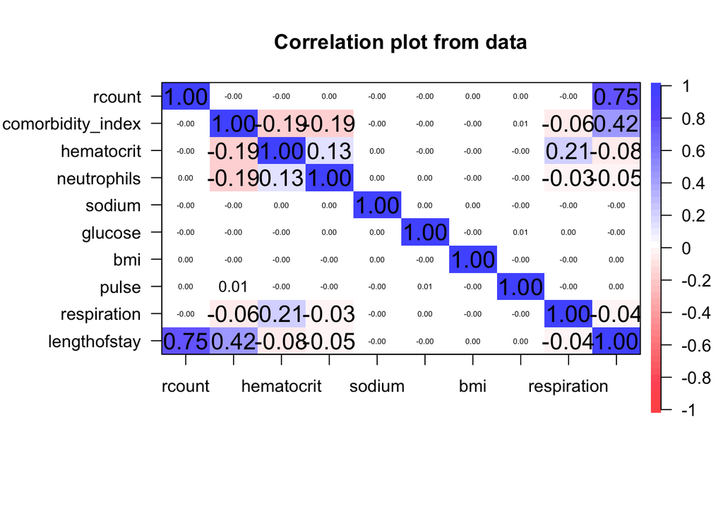

#### Outlier Removal

```r
# Duplicating length_of_stay_clean into length_of_stay_no
length_of_stay_no = length_of_stay_clean


# Logical vector to keep track of rows to keep
rows_to_keep = rep(TRUE, nrow(length_of_stay_clean))


# Vector to track columns with outliers
columns_with_outliers = c()


# For loop for outlier detection and removal
for (i in names( length_of_stay_clean[ seq( 7 ,  13 ) ] ) )  {

  m = mean(length_of_stay_clean[, i])

  s = sd(length_of_stay_clean[, i])

  z = (length_of_stay_clean[, i] - m) / s

  # Checking if there are outliers in the current column
  if (any( abs( z ) > 3 ) )
    {

    columns_with_outliers = c(columns_with_outliers, i)

   }

  rows_to_keep = rows_to_keep & (abs(z) <= 3)
}


# Overwriting length_of_stay_no created above to have no outliers
length_of_stay_no = length_of_stay_clean[rows_to_keep,]


# Number of rows before and after outlier removal
original_rows = nrow(length_of_stay_clean)
rows_after_removal = nrow(length_of_stay_no)


print(paste("Number of rows before outlier removal: ", original_rows))
```

```
## [1] "Number of rows before outlier removal:  100000"
```

```r
print(paste("Number of rows after outlier removal: ", rows_after_removal))
```

```
## [1] "Number of rows after outlier removal:  95023"
```

```r
print("Columns with outliers:")
```

```
## [1] "Columns with outliers:"
```

```r
print(columns_with_outliers)
```

```
## [1] "hematocrit"  "neutrophils" "sodium"      "glucose"     "bmi"
## [6] "pulse"       "respiration"
```

- The number of outliers in this dataset are only 5%.
- Considering this small percentage, I decided to remove outliers since there impact will not be significant.

### Model Building on Clean dataset

#### LR Model built after data prep

```r
# Building LR model
new_model = lm( lengthofstay ~. , data = train_data_clean )

summary(new_model)
```

```
##
## Call:
## lm(formula = lengthofstay ~ ., data = train_data_clean)
##
## Residuals:
##     Min      1Q  Median      3Q     Max
## -3.0774 -0.8167 -0.2361  0.5982  9.6672
##
## Coefficients:
##                                   Estimate Std. Error t value Pr(>|t|)
## (Intercept)                      1.7370762  0.0103542 167.766  < 2e-16 ***
## rcount                           1.1513363  0.0028363 405.929  < 2e-16 ***
## gender1                          0.1040364  0.0095404  10.905  < 2e-16 ***
## facid2                           0.0001264  0.0112761   0.011   0.9911
## facid3                           0.8741259  0.0229210  38.136  < 2e-16 ***
## facid4                           0.7211362  0.0235414  30.633  < 2e-16 ***
## facid5                           0.8429451  0.0155226  54.304  < 2e-16 ***
## weekend1                        -0.0164056  0.0096597  -1.698   0.0894 .
## kidney_statusProtein Deficiency  0.2404249  0.0098696  24.360  < 2e-16 ***
## kidney_statusRenal Impairment    0.5103590  0.0165610  30.817  < 2e-16 ***
## comorbidity_index                0.5885429  0.0064808  90.813  < 2e-16 ***
## hematocrit                      -0.0666346  0.0051746 -12.877  < 2e-16 ***
## neutrophils                      0.0965567  0.0052749  18.305  < 2e-16 ***
## sodium                           0.0017648  0.0044360   0.398   0.6907
## glucose                         -0.0031730  0.0044440  -0.714   0.4752
## bmi                              0.0015758  0.0044374   0.355   0.7225
## pulse                           -0.0096752  0.0044663  -2.166   0.0303 *
## respiration                      0.0336607  0.0056092   6.001 1.97e-09 ***
## ---
## Signif. codes:  0 '***' 0.001 '**' 0.01 '*' 0.05 '.' 0.1 ' ' 1
##
## Residual standard error: 1.127 on 66500 degrees of freedom
## Multiple R-squared:  0.7675, Adjusted R-squared:  0.7674
## F-statistic: 1.291e+04 on 17 and 66500 DF,  p-value: < 2.2e-16
```

```r
# Getting RMSE
RMSE_new_model = sqrt(mean(((round(predict( new_model , test_data_clean[-14] )) - test_data_clean$lengthofstay)^2 ) ) )
```

#### CV for L.R

```r
# For reproducibility
set.seed(123)

# 50-fold cross-validation
train_control = trainControl(method = "cv", number = 50)

# Creating LR model
cv_new_model = train( lengthofstay ~ . ,  data = train_data_clean,  method = "lm",  trControl = train_control )



# Getting RMSE
sqrt(mean(((round(predict( cv_new_model , test_data_clean[-14] )) - test_data_clean$lengthofstay)^2 ) ) )
```

```
## [1] 1.174198
```

- The R squared value for model after data prep is 0.7674606 while before doing data prep was 0.7606524 .
- There is not a significant difference in R square value and RMSE. The model after data prep is making little less errors as compared to before.
- The RMSE score for model with no data prep was 1.193153 whereas now it is 1.1741978.
- Cross fold cross validation has also nnot produced siginificant difference in results.

#### Step model on new LR model

```r
step_new_model = step( new_model , train_data_clean , direction = "backward" )
```

#### Evaluation

```r
rmse_step_new_model = sqrt(mean((round(predict( step_new_model , test_data_clean)) - test_data_clean$lengthofstay)^2))

rmse_step_new_model
```

```
## [1] 1.173839
```

- The RMSE for my step model with no data prep was 1.1925242 whereas the rmse score for this step model with data prep is 1.1738393. Since the RMSE has decreased slightly hence we can safely say that our new model has better fit compared to our previous model.

#### Random Forest Model

```r
library(randomForest)


rf = randomForest( lengthofstay ~. , data = train_data_clean , ntree = 10 )

rf
```

```
##
## Call:
##  randomForest(formula = lengthofstay ~ ., data = train_data_clean,      ntree = 10)
##                Type of random forest: regression
##                      Number of trees: 10
## No. of variables tried at each split: 4
##
##           Mean of squared residuals: 0.6255355
##                     % Var explained: 88.55
```

```r
# Evalaution
p = round(predict( rf , newdata = test_data_clean  ))

#p

# RMSE for random forest mdoel
rmse_rf = sqrt(mean((p - test_data_clean$lengthofstay)^2))
rmse_rf
```

```
## [1] 0.7354267
```

#### Hyperparameter tuning for random forest model

```r
control = trainControl(method = "cv", number = 3 , verboseIter = TRUE)

tunegrid = expand.grid(.mtry = c( 2 , 4 ))


set.seed(1234)

after_dataprep_rfmodel = train( train_data_clean , train_data_clean$lengthofstay  ,

                  method = "rf",

                  trControl = control,

                  tuneGrid = tunegrid,

                  ntree = 50)

after_dataprep_rfmodel





# RMSE
after_dataprep_rmse_rfmodel = sqrt(mean((round(predict( after_dataprep_rfmodel , test_data_clean )) - test_data_clean$lengthofstay)^2))

after_dataprep_rmse_rfmodel
```

[output not shown]

- **method** = “rf”: This tells the train function to use the Random Forest algorithm for modeling.
- **trControl** = control: control is where you specify how you want the training process to be controlled. In this case, it’s using cross-validation with 3 folds.
- **tuneGrid** = tunegrid: tunegrid contains the hyperparameters you want to test. For Random Forest, the key parameter here is .mtry, which is the number of variables to try at each split in the trees.
- **ntree** = 50: This specifies the number of trees to grow in the Random Forest. More trees usually mean better performance, but also more computation time.
- **number** = 3 in trainControl: This sets up 3-fold cross-validation, meaning the data is split into 3 parts, and the model is trained and validated 3 times, each time with a different part as the validation set and the other two as training sets.
- **verboseIter** = TRUE in trainControl: This makes the process print out progress updates as it trains the model, so you can see how it’s doing.

#### Gradient Boosting

```r
library(caret)

# Define the control parameters for training
control = trainControl(method = "cv", number = 3, verboseIter = TRUE)  # Fewer folds

# Define a reduced grid of hyperparameters to tune
tunegrid = expand.grid(
  .n.trees = c(10, 50),               # trees

  .interaction.depth = c(1, 3),        # depth levels

  .shrinkage = c(0.01, 0.1),           # learning rates

  .n.minobsinnode = c(10, 20)          # minimum observations

)

# Training the model using the specified hyperparameters
set.seed(1234)

gbmmodel = train( lengthofstay ~ ., data = train_data_clean, method = "gbm", trControl = control, tuneGrid = tunegrid, verbose = FALSE  )




rmse_GBM_model = sqrt(mean((round(predict( gbmmodel , test_data_clean )) - test_data_clean$lengthofstay)^2))

rmse_GBM_model


# RMSE for gradient boosting model is more than for random forest model
```

[output not shown]

#### RMSE and R square for models built so far

[output not shown]

Model Performance Metrics

[output not shown]

# 3rd Iteration

### Principal Component Analysis

```r
# Installing Packages
# install.packages("MASS")
# install.packages("factoextra")


# Loading Libraries
library(MASS)
library(factoextra)
library(ggplot2)
```

[output not shown]

```r
# Getting PCA
pca_result = prcomp(length_of_stay_clean_numeric  )

# summary
summary( pca_result)
```

```
## Importance of components:
##                           PC1    PC2     PC3     PC4     PC5     PC6     PC7
## Standard deviation     2.7630 1.7993 1.01520 0.98747 0.98670 0.98567 0.97766
## Proportion of Variance 0.4072 0.1727 0.05497 0.05201 0.05193 0.05182 0.05098
## Cumulative Proportion  0.4072 0.5798 0.63482 0.68683 0.73876 0.79058 0.84156
##                            PC8    PC9    PC10    PC11    PC12    PC13    PC14
## Standard deviation     0.85200 0.7710 0.73838 0.60804 0.57387 0.45240 0.44872
## Proportion of Variance 0.03872 0.0317 0.02908 0.01972 0.01757 0.01092 0.01074
## Cumulative Proportion  0.88028 0.9120 0.94106 0.96078 0.97834 0.98926 1.00000
```

```r
# Building df that stores new feature values
pca_data = as.data.frame(pca_result$x)
```

- We have got 9 components that can explain upto 91% variance in data

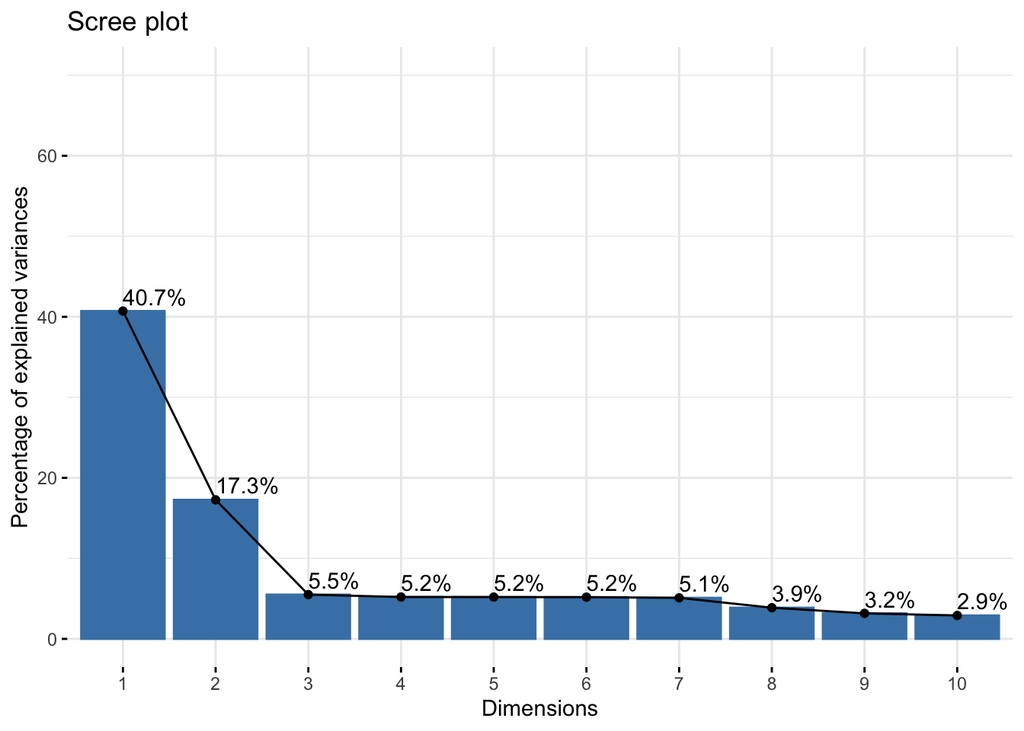

```r
# Scree Plot of Variance
fviz_eig( pca_result ,  addlabels = TRUE, ylim = c( 0 , 70  ) )
```

```r
# For reproducibility
set.seed(123)

trainIndex = createDataPartition( length_of_stay_clean_numeric$lengthofstay , p = .7,

                                  list = FALSE,  times = 1)

trainData = pca_data[trainIndex, ]

testData = pca_data[-trainIndex, ]

trainTarget = length_of_stay_clean_numeric$lengthofstay[trainIndex]


testTarget = length_of_stay_clean_numeric$lengthofstay[-trainIndex]
```

#### Building Linear Regression Model

```r
# Getting 9 components
num_components = 9

pca_features_train = trainData[, 1:num_components]

pca_features_test = testData[, 1:num_components]

# Fit the model
pca_lr_model = lm( trainTarget ~ ., data = data.frame(trainTarget, pca_features_train) )

# Summarize the model
summary(pca_lr_model)
```

```
##
## Call:
## lm(formula = trainTarget ~ ., data = data.frame(trainTarget,
##     pca_features_train))
##
## Residuals:
##     Min      1Q  Median      3Q     Max
## -1.2941 -0.1374 -0.0248  0.1334  1.5769
##
## Coefficients:
##               Estimate Std. Error  t value Pr(>|t|)
## (Intercept)  3.9457928  0.0009561 4127.027  < 2e-16 ***
## PC1          0.8303964  0.0003459 2400.359  < 2e-16 ***
## PC2          0.1380437  0.0005320  259.482  < 2e-16 ***
## PC3          0.0639778  0.0009422   67.900  < 2e-16 ***
## PC4         -0.0019064  0.0009687   -1.968   0.0491 *
## PC5         -0.0046346  0.0009666   -4.795 1.63e-06 ***
## PC6         -0.0061276  0.0009691   -6.323 2.58e-10 ***
## PC7          0.0047690  0.0009765    4.884 1.04e-06 ***
## PC8         -0.0661768  0.0011216  -59.000  < 2e-16 ***
## PC9          0.3375721  0.0012413  271.951  < 2e-16 ***
## ---
## Signif. codes:  0 '***' 0.001 '**' 0.01 '*' 0.05 '.' 0.1 ' ' 1
##
## Residual standard error: 0.2466 on 66508 degrees of freedom
## Multiple R-squared:  0.9889, Adjusted R-squared:  0.9889
## F-statistic: 6.574e+05 on 9 and 66508 DF,  p-value: < 2.2e-16
```

```r
# Predict on the test set
predictions = predict( pca_lr_model , newdata = data.frame( pca_features_test ) )

# Calculate performance metrics
rmse_pca_lr_model = sqrt(mean((predictions - testTarget)^2))
rmse_pca_lr_model
```

```
## [1] 0.2477109
```

```r
r_squared = cor(predictions, testTarget)^2

cat("RMSE: ", rmse_pca_lr_model, "\n")
```

```
## RMSE:  0.2477109
```

```r
cat("R-squared: ", r_squared, "\n")
```

```
## R-squared:  0.9887315
```

#### Building Step Model

```r
pca_step_model =  step( pca_lr_model , data = data.frame(trainTarget, pca_features_train) , direction = "backward" )
```

```
## Start:  AIC=-186251.5
## trainTarget ~ PC1 + PC2 + PC3 + PC4 + PC5 + PC6 + PC7 + PC8 +
##     PC9
##
##        Df Sum of Sq    RSS     AIC
## <none>                4044 -186251
## - PC4   1         0   4044 -186250
## - PC5   1         1   4045 -186230
## - PC7   1         1   4045 -186230
## - PC6   1         2   4046 -186213
## - PC8   1       212   4255 -182860
## - PC3   1       280   4324 -181795
## - PC2   1      4094   8137 -139737
## - PC9   1      4497   8540 -136522
## - PC1   1    350313 354356  111291
```

```r
# Getting predictions
predictions_step = predict( pca_step_model , newdata = data.frame( pca_features_test ) )


# Evaluation
rmse_pca_step_model =  sqrt(mean((predictions_step - testTarget)^2))

rmse_pca_step_model
```

```
## [1] 0.2477109
```

```r
# R-squared
r_square_step =  cor( predictions_step, testTarget)^2
```

#### Building Random Forest Model

```r
# Loading necessary libraries
library(randomForest)




# Train the model
pca_rf_model = randomForest( trainTarget ~ ., data = data.frame(trainTarget, pca_features_train) , ntree = 10)

# Summary of the model
print(pca_rf_model)
```

```
##
## Call:
##  randomForest(formula = trainTarget ~ ., data = data.frame(trainTarget,      pca_features_train), ntree = 10)
##                Type of random forest: regression
##                      Number of trees: 10
## No. of variables tried at each split: 3
##
##           Mean of squared residuals: 0.06346255
##                     % Var explained: 98.84
```

```r
predictions_rf = predict( pca_rf_model , newdata = data.frame( pca_features_test ) )


# R squared
r_square_rf =  cor( predictions_rf, testTarget)^2
r_square_rf
```

```
## [1] 0.9944197
```

```r
# Evaluation
rmse_pca_rf_model = sqrt(mean((predictions_rf - testTarget)^2))

rmse_pca_rf_model
```

```
## [1] 0.1757657
```

#### Building gradient boosting model

```r
library(caret)

# Define the control parameters for training
control = trainControl(method = "cv", number = 3, verboseIter = TRUE)



# Define a reduced grid of hyperparameters to tune
tunegrid = expand.grid( n.trees = c(10, 50) , interaction.depth = c(1, 3), n.minobsinnode = c(10, 20) , shrinkage = c(0.01, 0.1)  )



# Train the model using the specified hyperparameters
set.seed(1234)


gbm_model_pca = train( trainTarget ~ ., data = data.frame(trainTarget, pca_features_train) , method = "gbm", trControl = control, tuneGrid = tunegrid, verbose = FALSE )



# Getting predictions
predictions_gbm = predict( gbm_model_pca , newdata = data.frame( pca_features_test ) )


rmse_GBM_PCA_model = sqrt(mean((predictions_gbm - testTarget)^2))

rmse_GBM_PCA_model



# R squared
r_square_gbm =  cor( predictions_gbm, testTarget)^2
```

[output not shown]

Updated Model Performance Metrics

[output not shown]

### Ensemble Model

```r
# Creating ensemble
ensemble_models = function( test_data_clean ,  target_var , lm_model , rf_model , gbm_model , weights )  {



  # Using my best models based on R square and RMSE
  pred_lm = predict(new_model, newdata = test_data_clean)

  pred_rf = predict(after_dataprep_rfmodel, newdata = test_data_clean)

  pred_gbm = predict(gbmmodel, newdata = test_data_clean)


  # Assigning weights as random forest and gbm model perform better than linear regression
  final_predictions = (weights[1] * pred_lm + weights[2] * pred_rf + weights[3] * pred_gbm) / sum(weights)


  # Getting rnse and r square
  final_rmse = sqrt(mean((final_predictions - test_data_clean[[target_var]])^2))

  final_r_squared = cor(final_predictions, test_data_clean[[target_var]])^2

  list(final_rmse = final_rmse, final_r_squared = final_r_squared )


}

# Assigning weights
weights = c(0.2, 0.6, 0.4)

result = ensemble_models(test_data_clean, "lengthofstay", lm_model, rf_model, gbm_model, weights)

print(result)
```

```
## $final_rmse
## [1] 0.4624115
##
## $final_r_squared
## [1] 0.9684052
```

# Observations